# Risk Factor Analysis

## Outcome Variable

**Outcome Variable:** ever_stunted

## Predictor Variables

**Intervention Variable:** tr.x

**Adjustment Set:**

unadjusted

## Stratifying Variables

The analysis was stratified on these variable(s):

- nrooms
- agecat
- studyid
- country

## Data Summary

| nrooms | agecat | studyid | country | tr.x | ever_stunted | n_cell | n |
| --- | --- | --- | --- | --- | --- | --- | --- |
| 1 | 0-6 months | ki1000125-AgaKhanUniv | PAKISTAN | Control | 0 | 10 | 32 |
| 1 | 0-6 months | ki1000125-AgaKhanUniv | PAKISTAN | Control | 1 | 5 | 32 |
| 1 | 0-6 months | ki1000125-AgaKhanUniv | PAKISTAN | Other | 0 | 12 | 32 |
| 1 | 0-6 months | ki1000125-AgaKhanUniv | PAKISTAN | Other | 1 | 5 | 32 |
| 2 | 0-6 months | ki1000125-AgaKhanUniv | PAKISTAN | Control | 0 | 13 | 34 |
| 2 | 0-6 months | ki1000125-AgaKhanUniv | PAKISTAN | Control | 1 | 5 | 34 |
| 2 | 0-6 months | ki1000125-AgaKhanUniv | PAKISTAN | Other | 0 | 13 | 34 |
| 2 | 0-6 months | ki1000125-AgaKhanUniv | PAKISTAN | Other | 1 | 3 | 34 |
| 4+ | 0-6 months | ki1000125-AgaKhanUniv | PAKISTAN | Control | 0 | 7 | 16 |
| 4+ | 0-6 months | ki1000125-AgaKhanUniv | PAKISTAN | Control | 1 | 1 | 16 |
| 4+ | 0-6 months | ki1000125-AgaKhanUniv | PAKISTAN | Other | 0 | 8 | 16 |
| 4+ | 0-6 months | ki1000125-AgaKhanUniv | PAKISTAN | Other | 1 | 0 | 16 |
| 3 | 0-6 months | ki1000125-AgaKhanUniv | PAKISTAN | Control | 0 | 5 | 15 |
| 3 | 0-6 months | ki1000125-AgaKhanUniv | PAKISTAN | Control | 1 | 1 | 15 |
| 3 | 0-6 months | ki1000125-AgaKhanUniv | PAKISTAN | Other | 0 | 8 | 15 |
| 3 | 0-6 months | ki1000125-AgaKhanUniv | PAKISTAN | Other | 1 | 1 | 15 |
| 4+ | 0-6 months | ki1000304-VITAMIN-A | INDIA | Control | 0 | 7 | 20 |
| 4+ | 0-6 months | ki1000304-VITAMIN-A | INDIA | Control | 1 | 3 | 20 |
| 4+ | 0-6 months | ki1000304-VITAMIN-A | INDIA | Other | 0 | 8 | 20 |
| 4+ | 0-6 months | ki1000304-VITAMIN-A | INDIA | Other | 1 | 2 | 20 |
| 2 | 0-6 months | ki1000304-VITAMIN-A | INDIA | Control | 0 | 36 | 87 |
| 2 | 0-6 months | ki1000304-VITAMIN-A | INDIA | Control | 1 | 12 | 87 |
| 2 | 0-6 months | ki1000304-VITAMIN-A | INDIA | Other | 0 | 24 | 87 |
| 2 | 0-6 months | ki1000304-VITAMIN-A | INDIA | Other | 1 | 15 | 87 |
| 1 | 0-6 months | ki1000304-VITAMIN-A | INDIA | Control | 0 | 66 | 205 |
| 1 | 0-6 months | ki1000304-VITAMIN-A | INDIA | Control | 1 | 35 | 205 |
| 1 | 0-6 months | ki1000304-VITAMIN-A | INDIA | Other | 0 | 70 | 205 |
| 1 | 0-6 months | ki1000304-VITAMIN-A | INDIA | Other | 1 | 34 | 205 |
| 3 | 0-6 months | ki1000304-VITAMIN-A | INDIA | Control | 0 | 9 | 22 |
| 3 | 0-6 months | ki1000304-VITAMIN-A | INDIA | Control | 1 | 3 | 22 |

[output cut: 414 more lines]

The following strata were considered:

- nrooms: 1, agecat: 0-24 months, studyid: ki1000125-AgaKhanUniv, country: PAKISTAN
- nrooms: 1, agecat: 0-24 months, studyid: ki1000304-VITAMIN-A, country: INDIA
- nrooms: 1, agecat: 0-24 months, studyid: ki1000304-ZnMort, country: INDIA
- nrooms: 1, agecat: 0-24 months, studyid: ki1017093b-PROVIDE, country: BANGLADESH
- nrooms: 1, agecat: 0-24 months, studyid: ki1148112-iLiNS-DOSE, country: MALAWI
- nrooms: 1, agecat: 0-24 months, studyid: ki1148112-iLiNS-DYAD-M, country: MALAWI
- nrooms: 1, agecat: 0-24 months, studyid: kiGH5241-JiVitA-3, country: BANGLADESH
- nrooms: 1, agecat: 0-24 months, studyid: kiGH5241-JiVitA-4, country: BANGLADESH
- nrooms: 1, agecat: 0-6 months, studyid: ki1000125-AgaKhanUniv, country: PAKISTAN
- nrooms: 1, agecat: 0-6 months, studyid: ki1000304-VITAMIN-A, country: INDIA
- nrooms: 1, agecat: 0-6 months, studyid: ki1000304-ZnMort, country: INDIA
- nrooms: 1, agecat: 0-6 months, studyid: ki1017093b-PROVIDE, country: BANGLADESH
- nrooms: 1, agecat: 0-6 months, studyid: ki1148112-iLiNS-DOSE, country: MALAWI
- nrooms: 1, agecat: 0-6 months, studyid: ki1148112-iLiNS-DYAD-M, country: MALAWI
- nrooms: 1, agecat: 0-6 months, studyid: kiGH5241-JiVitA-3, country: BANGLADESH
- nrooms: 1, agecat: 0-6 months, studyid: kiGH5241-JiVitA-4, country: BANGLADESH
- nrooms: 1, agecat: 6-24 months, studyid: ki1000125-AgaKhanUniv, country: PAKISTAN
- nrooms: 1, agecat: 6-24 months, studyid: ki1000304-VITAMIN-A, country: INDIA
- nrooms: 1, agecat: 6-24 months, studyid: ki1000304-ZnMort, country: INDIA
- nrooms: 1, agecat: 6-24 months, studyid: ki1017093b-PROVIDE, country: BANGLADESH
- nrooms: 1, agecat: 6-24 months, studyid: ki1148112-iLiNS-DOSE, country: MALAWI
- nrooms: 1, agecat: 6-24 months, studyid: ki1148112-iLiNS-DYAD-M, country: MALAWI
- nrooms: 1, agecat: 6-24 months, studyid: kiGH5241-JiVitA-3, country: BANGLADESH
- nrooms: 1, agecat: 6-24 months, studyid: kiGH5241-JiVitA-4, country: BANGLADESH
- nrooms: 2, agecat: 0-24 months, studyid: ki1000125-AgaKhanUniv, country: PAKISTAN
- nrooms: 2, agecat: 0-24 months, studyid: ki1000304-VITAMIN-A, country: INDIA
- nrooms: 2, agecat: 0-24 months, studyid: ki1000304-ZnMort, country: INDIA
- nrooms: 2, agecat: 0-24 months, studyid: ki1017093b-PROVIDE, country: BANGLADESH
- nrooms: 2, agecat: 0-24 months, studyid: ki1148112-iLiNS-DOSE, country: MALAWI
- nrooms: 2, agecat: 0-24 months, studyid: ki1148112-iLiNS-DYAD-M, country: MALAWI
- nrooms: 2, agecat: 0-24 months, studyid: kiGH5241-JiVitA-3, country: BANGLADESH
- nrooms: 2, agecat: 0-24 months, studyid: kiGH5241-JiVitA-4, country: BANGLADESH
- nrooms: 2, agecat: 0-6 months, studyid: ki1000125-AgaKhanUniv, country: PAKISTAN
- nrooms: 2, agecat: 0-6 months, studyid: ki1000304-VITAMIN-A, country: INDIA
- nrooms: 2, agecat: 0-6 months, studyid: ki1000304-ZnMort, country: INDIA
- nrooms: 2, agecat: 0-6 months, studyid: ki1017093b-PROVIDE, country: BANGLADESH
- nrooms: 2, agecat: 0-6 months, studyid: ki1148112-iLiNS-DOSE, country: MALAWI
- nrooms: 2, agecat: 0-6 months, studyid: ki1148112-iLiNS-DYAD-M, country: MALAWI
- nrooms: 2, agecat: 0-6 months, studyid: kiGH5241-JiVitA-3, country: BANGLADESH
- nrooms: 2, agecat: 0-6 months, studyid: kiGH5241-JiVitA-4, country: BANGLADESH
- nrooms: 2, agecat: 6-24 months, studyid: ki1000125-AgaKhanUniv, country: PAKISTAN
- nrooms: 2, agecat: 6-24 months, studyid: ki1000304-VITAMIN-A, country: INDIA
- nrooms: 2, agecat: 6-24 months, studyid: ki1000304-ZnMort, country: INDIA
- nrooms: 2, agecat: 6-24 months, studyid: ki1017093b-PROVIDE, country: BANGLADESH
- nrooms: 2, agecat: 6-24 months, studyid: ki1148112-iLiNS-DOSE, country: MALAWI
- nrooms: 2, agecat: 6-24 months, studyid: ki1148112-iLiNS-DYAD-M, country: MALAWI
- nrooms: 2, agecat: 6-24 months, studyid: kiGH5241-JiVitA-3, country: BANGLADESH
- nrooms: 2, agecat: 6-24 months, studyid: kiGH5241-JiVitA-4, country: BANGLADESH
- nrooms: 3, agecat: 0-24 months, studyid: ki1000125-AgaKhanUniv, country: PAKISTAN
- nrooms: 3, agecat: 0-24 months, studyid: ki1000304-VITAMIN-A, country: INDIA
- nrooms: 3, agecat: 0-24 months, studyid: ki1000304-ZnMort, country: INDIA
- nrooms: 3, agecat: 0-24 months, studyid: ki1017093b-PROVIDE, country: BANGLADESH
- nrooms: 3, agecat: 0-24 months, studyid: ki1148112-iLiNS-DOSE, country: MALAWI
- nrooms: 3, agecat: 0-24 months, studyid: ki1148112-iLiNS-DYAD-M, country: MALAWI
- nrooms: 3, agecat: 0-24 months, studyid: kiGH5241-JiVitA-3, country: BANGLADESH
- nrooms: 3, agecat: 0-24 months, studyid: kiGH5241-JiVitA-4, country: BANGLADESH
- nrooms: 3, agecat: 0-6 months, studyid: ki1000125-AgaKhanUniv, country: PAKISTAN
- nrooms: 3, agecat: 0-6 months, studyid: ki1000304-VITAMIN-A, country: INDIA
- nrooms: 3, agecat: 0-6 months, studyid: ki1000304-ZnMort, country: INDIA
- nrooms: 3, agecat: 0-6 months, studyid: ki1017093b-PROVIDE, country: BANGLADESH
- nrooms: 3, agecat: 0-6 months, studyid: ki1148112-iLiNS-DOSE, country: MALAWI
- nrooms: 3, agecat: 0-6 months, studyid: ki1148112-iLiNS-DYAD-M, country: MALAWI
- nrooms: 3, agecat: 0-6 months, studyid: kiGH5241-JiVitA-3, country: BANGLADESH
- nrooms: 3, agecat: 0-6 months, studyid: kiGH5241-JiVitA-4, country: BANGLADESH
- nrooms: 3, agecat: 6-24 months, studyid: ki1000125-AgaKhanUniv, country: PAKISTAN
- nrooms: 3, agecat: 6-24 months, studyid: ki1000304-VITAMIN-A, country: INDIA
- nrooms: 3, agecat: 6-24 months, studyid: ki1000304-ZnMort, country: INDIA
- nrooms: 3, agecat: 6-24 months, studyid: ki1017093b-PROVIDE, country: BANGLADESH
- nrooms: 3, agecat: 6-24 months, studyid: ki1148112-iLiNS-DOSE, country: MALAWI
- nrooms: 3, agecat: 6-24 months, studyid: ki1148112-iLiNS-DYAD-M, country: MALAWI
- nrooms: 3, agecat: 6-24 months, studyid: kiGH5241-JiVitA-3, country: BANGLADESH
- nrooms: 3, agecat: 6-24 months, studyid: kiGH5241-JiVitA-4, country: BANGLADESH
- nrooms: 4+, agecat: 0-24 months, studyid: ki1000125-AgaKhanUniv, country: PAKISTAN
- nrooms: 4+, agecat: 0-24 months, studyid: ki1000304-VITAMIN-A, country: INDIA
- nrooms: 4+, agecat: 0-24 months, studyid: ki1000304-ZnMort, country: INDIA
- nrooms: 4+, agecat: 0-24 months, studyid: ki1017093b-PROVIDE, country: BANGLADESH
- nrooms: 4+, agecat: 0-24 months, studyid: ki1148112-iLiNS-DOSE, country: MALAWI
- nrooms: 4+, agecat: 0-24 months, studyid: ki1148112-iLiNS-DYAD-M, country: MALAWI
- nrooms: 4+, agecat: 0-24 months, studyid: kiGH5241-JiVitA-3, country: BANGLADESH
- nrooms: 4+, agecat: 0-24 months, studyid: kiGH5241-JiVitA-4, country: BANGLADESH
- nrooms: 4+, agecat: 0-6 months, studyid: ki1000125-AgaKhanUniv, country: PAKISTAN
- nrooms: 4+, agecat: 0-6 months, studyid: ki1000304-VITAMIN-A, country: INDIA
- nrooms: 4+, agecat: 0-6 months, studyid: ki1000304-ZnMort, country: INDIA
- nrooms: 4+, agecat: 0-6 months, studyid: ki1017093b-PROVIDE, country: BANGLADESH
- nrooms: 4+, agecat: 0-6 months, studyid: ki1148112-iLiNS-DOSE, country: MALAWI
- nrooms: 4+, agecat: 0-6 months, studyid: ki1148112-iLiNS-DYAD-M, country: MALAWI
- nrooms: 4+, agecat: 0-6 months, studyid: kiGH5241-JiVitA-3, country: BANGLADESH
- nrooms: 4+, agecat: 0-6 months, studyid: kiGH5241-JiVitA-4, country: BANGLADESH
- nrooms: 4+, agecat: 6-24 months, studyid: ki1000125-AgaKhanUniv, country: PAKISTAN
- nrooms: 4+, agecat: 6-24 months, studyid: ki1000304-VITAMIN-A, country: INDIA
- nrooms: 4+, agecat: 6-24 months, studyid: ki1000304-ZnMort, country: INDIA
- nrooms: 4+, agecat: 6-24 months, studyid: ki1017093b-PROVIDE, country: BANGLADESH
- nrooms: 4+, agecat: 6-24 months, studyid: ki1148112-iLiNS-DOSE, country: MALAWI
- nrooms: 4+, agecat: 6-24 months, studyid: ki1148112-iLiNS-DYAD-M, country: MALAWI
- nrooms: 4+, agecat: 6-24 months, studyid: kiGH5241-JiVitA-3, country: BANGLADESH
- nrooms: 4+, agecat: 6-24 months, studyid: kiGH5241-JiVitA-4, country: BANGLADESH

### Dropped Strata

Some strata were dropped due to rare outcomes:

- nrooms: 2, agecat: 0-6 months, studyid: ki1000125-AgaKhanUniv, country: PAKISTAN
- nrooms: 4+, agecat: 0-6 months, studyid: ki1000125-AgaKhanUniv, country: PAKISTAN
- nrooms: 3, agecat: 0-6 months, studyid: ki1000125-AgaKhanUniv, country: PAKISTAN
- nrooms: 4+, agecat: 0-6 months, studyid: ki1000304-VITAMIN-A, country: INDIA
- nrooms: 3, agecat: 0-6 months, studyid: ki1000304-VITAMIN-A, country: INDIA
- nrooms: 4+, agecat: 0-6 months, studyid: ki1000304-ZnMort, country: INDIA
- nrooms: 3, agecat: 0-6 months, studyid: ki1000304-ZnMort, country: INDIA
- nrooms: 2, agecat: 0-6 months, studyid: ki1017093b-PROVIDE, country: BANGLADESH
- nrooms: 4+, agecat: 0-6 months, studyid: ki1017093b-PROVIDE, country: BANGLADESH
- nrooms: 3, agecat: 0-6 months, studyid: ki1017093b-PROVIDE, country: BANGLADESH
- nrooms: 4+, agecat: 0-6 months, studyid: ki1148112-iLiNS-DOSE, country: MALAWI
- nrooms: 3, agecat: 0-6 months, studyid: ki1148112-iLiNS-DYAD-M, country: MALAWI
- nrooms: 2, agecat: 0-6 months, studyid: ki1148112-iLiNS-DYAD-M, country: MALAWI
- nrooms: 1, agecat: 0-6 months, studyid: ki1148112-iLiNS-DYAD-M, country: MALAWI
- nrooms: 4+, agecat: 0-6 months, studyid: ki1148112-iLiNS-DYAD-M, country: MALAWI
- nrooms: 3, agecat: 6-24 months, studyid: ki1000125-AgaKhanUniv, country: PAKISTAN
- nrooms: 2, agecat: 6-24 months, studyid: ki1000125-AgaKhanUniv, country: PAKISTAN
- nrooms: 4+, agecat: 6-24 months, studyid: ki1000125-AgaKhanUniv, country: PAKISTAN
- nrooms: 1, agecat: 6-24 months, studyid: ki1000125-AgaKhanUniv, country: PAKISTAN
- nrooms: 2, agecat: 6-24 months, studyid: ki1017093b-PROVIDE, country: BANGLADESH
- nrooms: 4+, agecat: 6-24 months, studyid: ki1017093b-PROVIDE, country: BANGLADESH
- nrooms: 3, agecat: 6-24 months, studyid: ki1017093b-PROVIDE, country: BANGLADESH
- nrooms: 3, agecat: 6-24 months, studyid: ki1148112-iLiNS-DYAD-M, country: MALAWI
- nrooms: 4+, agecat: 6-24 months, studyid: ki1148112-iLiNS-DYAD-M, country: MALAWI
- nrooms: 3, agecat: 0-24 months, studyid: ki1000125-AgaKhanUniv, country: PAKISTAN
- nrooms: 4+, agecat: 0-24 months, studyid: ki1000125-AgaKhanUniv, country: PAKISTAN
- nrooms: 4+, agecat: 0-24 months, studyid: ki1017093b-PROVIDE, country: BANGLADESH
- nrooms: 4+, agecat: 0-24 months, studyid: ki1148112-iLiNS-DYAD-M, country: MALAWI

## Methods Detail

We’re interested in the causal parameters $E[Y_a]$ for all values of $a \in \mathcal{A}$. These parameters represent the mean outcome if, possibly contrary to fact, we intervened to set all units to have $A=a$. Under the randomization and positivity assumptions, these are identified by the statistical parameters $\psi_a=E_W[E_{Y|A,W}(Y|A=a,W)]$. In addition, we’re interested in the mean of $Y$, $E[Y]$ under no intervention (the observed mean). We will estimate these parameters by using SuperLearner to fit the relevant likelihood factors – $E_{Y|A,W}(Y|A=a,W)$ and $p(A=a|W)$, and then updating our likelihood fit using a joint TMLE.

For unadjusted analyses ($W=\{\}$), initial likelihoods were estimated using Lrnr_glm to estimate the simple $E(Y|A)$ and Lrnr_mean to estimate $p(A)$. For adjusted analyses, a small library containing Lrnr_glmnet, Lrnr_xgboost, and Lrnr_mean was used.

Having estimated these parameters, we will then use the delta method to estimate relative risks and attributable risks relative to a prespecified baseline level of $A$.

[output not shown]

# Results Detail

## Results Plots

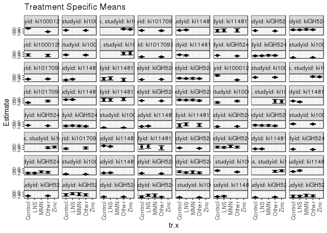

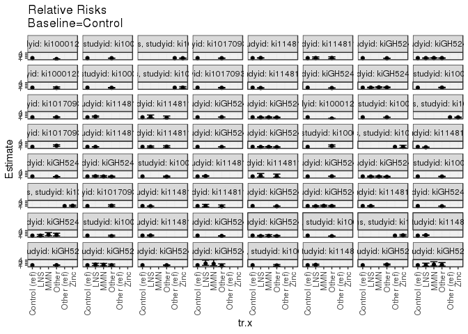

[figure not shown]

[figure not shown]

## Results Table

### Parameter: TSM

| nrooms | agecat | studyid | country | intervention_level | baseline_level | estimate | ci_lower | ci_upper |
| --- | --- | --- | --- | --- | --- | --- | --- | --- |
| 1 | 0-24 months | ki1000125-AgaKhanUniv | PAKISTAN | Control | NA | 0.6639004 | 0.6107660 | 0.7170348 |
| 1 | 0-24 months | ki1000125-AgaKhanUniv | PAKISTAN | Other | NA | 0.3333333 | 0.3146250 | 0.3520417 |
| 1 | 0-24 months | ki1000304-VITAMIN-A | INDIA | Control | NA | 0.4712230 | 0.4563428 | 0.4861033 |
| 1 | 0-24 months | ki1000304-VITAMIN-A | INDIA | Other | NA | 0.4560592 | 0.4414203 | 0.4706981 |
| 1 | 0-24 months | ki1000304-ZnMort | INDIA | Other | NA | 0.5885947 | 0.5450456 | 0.6321439 |
| 1 | 0-24 months | ki1000304-ZnMort | INDIA | Zinc | NA | 0.5579869 | 0.5124305 | 0.6035432 |
| 1 | 0-24 months | ki1017093b-PROVIDE | BANGLADESH | Control | NA | 0.4482759 | 0.4253792 | 0.4711725 |
| 1 | 0-24 months | ki1017093b-PROVIDE | BANGLADESH | Other | NA | 0.4314869 | 0.3922757 | 0.4706981 |
| 1 | 0-24 months | ki1148112-iLiNS-DOSE | MALAWI | Control | NA | 0.4629630 | 0.4418095 | 0.4841164 |
| 1 | 0-24 months | ki1148112-iLiNS-DOSE | MALAWI | LNS | NA | 0.5034965 | 0.4546817 | 0.5523113 |
| 1 | 0-24 months | ki1148112-iLiNS-DYAD-M | MALAWI | Control | NA | 0.4200000 | 0.2826533 | 0.5573467 |
| 1 | 0-24 months | ki1148112-iLiNS-DYAD-M | MALAWI | LNS | NA | 0.4523810 | 0.3012576 | 0.6035043 |
| 1 | 0-24 months | ki1148112-iLiNS-DYAD-M | MALAWI | Other | NA | 0.4571429 | 0.2914517 | 0.6228340 |
| 1 | 0-24 months | kiGH5241-JiVitA-3 | BANGLADESH | Control | NA | 0.4322125 | 0.4248093 | 0.4396157 |
| 1 | 0-24 months | kiGH5241-JiVitA-3 | BANGLADESH | Other | NA | 0.4016560 | 0.3948171 | 0.4084949 |
| 1 | 0-24 months | kiGH5241-JiVitA-4 | BANGLADESH | Control | NA | 0.5140187 | 0.4706550 | 0.5573824 |
| 1 | 0-24 months | kiGH5241-JiVitA-4 | BANGLADESH | LNS | NA | 0.5134855 | 0.4717559 | 0.5552151 |
| 1 | 0-24 months | kiGH5241-JiVitA-4 | BANGLADESH | MMN | NA | 0.5503080 | 0.4910928 | 0.6095232 |
| 1 | 0-24 months | kiGH5241-JiVitA-4 | BANGLADESH | Other | NA | 0.5237557 | 0.4843463 | 0.5631651 |
| 1 | 0-6 months | ki1000125-AgaKhanUniv | PAKISTAN | Control | NA | 0.3333333 | 0.2197194 | 0.4469473 |
| 1 | 0-6 months | ki1000125-AgaKhanUniv | PAKISTAN | Other | NA | 0.2941176 | 0.1772099 | 0.4110254 |
| 1 | 0-6 months | ki1000304-VITAMIN-A | INDIA | Control | NA | 0.3465347 | 0.3006992 | 0.3923701 |
| 1 | 0-6 months | ki1000304-VITAMIN-A | INDIA | Other | NA | 0.3269231 | 0.2810743 | 0.3727719 |
| 1 | 0-6 months | ki1000304-ZnMort | INDIA | Other | NA | 0.4782609 | 0.3330187 | 0.6235030 |
| 1 | 0-6 months | ki1000304-ZnMort | INDIA | Zinc | NA | 0.5000000 | 0.3356645 | 0.6643355 |
| 1 | 0-6 months | ki1017093b-PROVIDE | BANGLADESH | Control | NA | 0.1551724 | 0.1384662 | 0.1718786 |
| 1 | 0-6 months | ki1017093b-PROVIDE | BANGLADESH | Other | NA | 0.1461988 | 0.1182077 | 0.1741900 |
| 1 | 0-6 months | ki1148112-iLiNS-DOSE | MALAWI | Control | NA | 0.3548387 | 0.3302678 | 0.3794096 |
| 1 | 0-6 months | ki1148112-iLiNS-DOSE | MALAWI | LNS | NA | 0.2967033 | 0.2398630 | 0.3535436 |
| 1 | 0-6 months | kiGH5241-JiVitA-3 | BANGLADESH | Control | NA | 0.2873270 | 0.2803708 | 0.2942832 |

[output cut: 127 more lines]

### Parameter: E(Y)

| nrooms | agecat | studyid | country | intervention_level | baseline_level | estimate | ci_lower | ci_upper |
| --- | --- | --- | --- | --- | --- | --- | --- | --- |
| 1 | 0-24 months | ki1000125-AgaKhanUniv | PAKISTAN | NA | NA | 0.6273063 | 0.5696320 | 0.6849805 |
| 1 | 0-24 months | ki1000304-VITAMIN-A | INDIA | NA | NA | 0.4637483 | 0.4428720 | 0.4846246 |
| 1 | 0-24 months | ki1000304-ZnMort | INDIA | NA | NA | 0.5738397 | 0.5423437 | 0.6053356 |
| 1 | 0-24 months | ki1017093b-PROVIDE | BANGLADESH | NA | NA | 0.4357298 | 0.3903182 | 0.4811415 |
| 1 | 0-24 months | ki1148112-iLiNS-DOSE | MALAWI | NA | NA | 0.4970588 | 0.4438344 | 0.5502832 |
| 1 | 0-24 months | ki1148112-iLiNS-DYAD-M | MALAWI | NA | NA | 0.4409449 | 0.3542522 | 0.5276375 |
| 1 | 0-24 months | kiGH5241-JiVitA-3 | BANGLADESH | NA | NA | 0.4165112 | 0.4063052 | 0.4267171 |
| 1 | 0-24 months | kiGH5241-JiVitA-4 | BANGLADESH | NA | NA | 0.5220934 | 0.4998196 | 0.5443671 |
| 1 | 0-6 months | ki1000125-AgaKhanUniv | PAKISTAN | NA | NA | 0.3125000 | 0.1493344 | 0.4756656 |
| 1 | 0-6 months | ki1000304-VITAMIN-A | INDIA | NA | NA | 0.3365854 | 0.2717409 | 0.4014299 |
| 1 | 0-6 months | ki1000304-ZnMort | INDIA | NA | NA | 0.4878049 | 0.3789504 | 0.5966594 |
| 1 | 0-6 months | ki1017093b-PROVIDE | BANGLADESH | NA | NA | 0.1484716 | 0.1158721 | 0.1810711 |
| 1 | 0-6 months | ki1148112-iLiNS-DOSE | MALAWI | NA | NA | 0.3051643 | 0.2431791 | 0.3671495 |
| 1 | 0-6 months | kiGH5241-JiVitA-3 | BANGLADESH | NA | NA | 0.2615371 | 0.2522555 | 0.2708187 |
| 1 | 0-6 months | kiGH5241-JiVitA-4 | BANGLADESH | NA | NA | 0.2693878 | 0.2488398 | 0.2899357 |
| 1 | 6-24 months | ki1000304-VITAMIN-A | INDIA | NA | NA | 0.0821705 | 0.0671785 | 0.0971626 |
| 1 | 6-24 months | ki1017093b-PROVIDE | BANGLADESH | NA | NA | 0.2664756 | 0.2200247 | 0.3129266 |
| 1 | 6-24 months | ki1148112-iLiNS-DOSE | MALAWI | NA | NA | 0.2304147 | 0.1742576 | 0.2865719 |
| 1 | 6-24 months | ki1148112-iLiNS-DYAD-M | MALAWI | NA | NA | 0.2700000 | 0.1825472 | 0.3574528 |
| 1 | 6-24 months | kiGH5241-JiVitA-3 | BANGLADESH | NA | NA | 0.2216324 | 0.2106001 | 0.2326646 |
| 1 | 6-24 months | kiGH5241-JiVitA-4 | BANGLADESH | NA | NA | 0.3185125 | 0.2957414 | 0.3412836 |
| 2 | 0-24 months | ki1000125-AgaKhanUniv | PAKISTAN | NA | NA | 0.5407725 | 0.4766478 | 0.6048972 |
| 2 | 0-24 months | ki1000304-VITAMIN-A | INDIA | NA | NA | 0.4246738 | 0.3912868 | 0.4580607 |
| 2 | 0-24 months | ki1000304-ZnMort | INDIA | NA | NA | 0.4856230 | 0.4464399 | 0.5248061 |
| 2 | 0-24 months | ki1017093b-PROVIDE | BANGLADESH | NA | NA | 0.3465347 | 0.2532666 | 0.4398027 |
| 2 | 0-24 months | ki1148112-iLiNS-DOSE | MALAWI | NA | NA | 0.5278174 | 0.4908349 | 0.5647999 |
| 2 | 0-24 months | ki1148112-iLiNS-DYAD-M | MALAWI | NA | NA | 0.5227273 | 0.4371943 | 0.6082602 |
| 2 | 0-24 months | kiGH5241-JiVitA-3 | BANGLADESH | NA | NA | 0.4122821 | 0.3975992 | 0.4269650 |
| 2 | 0-24 months | kiGH5241-JiVitA-4 | BANGLADESH | NA | NA | 0.4708003 | 0.4391080 | 0.5024926 |
| 2 | 0-6 months | ki1000304-VITAMIN-A | INDIA | NA | NA | 0.3103448 | 0.2125677 | 0.4081219 |
| 2 | 0-6 months | ki1000304-ZnMort | INDIA | NA | NA | 0.3508772 | 0.2258815 | 0.4758729 |
| 2 | 0-6 months | ki1148112-iLiNS-DOSE | MALAWI | NA | NA | 0.3195402 | 0.2756703 | 0.3634102 |
| 2 | 0-6 months | kiGH5241-JiVitA-3 | BANGLADESH | NA | NA | 0.2725024 | 0.2591088 | 0.2858960 |
| 2 | 0-6 months | kiGH5241-JiVitA-4 | BANGLADESH | NA | NA | 0.2333044 | 0.2039642 | 0.2626446 |
| 2 | 6-24 months | ki1000304-VITAMIN-A | INDIA | NA | NA | 0.0641509 | 0.0432712 | 0.0850307 |
| 2 | 6-24 months | ki1148112-iLiNS-DOSE | MALAWI | NA | NA | 0.2165899 | 0.1777911 | 0.2553886 |
| 2 | 6-24 months | ki1148112-iLiNS-DYAD-M | MALAWI | NA | NA | 0.3398058 | 0.2478881 | 0.4317235 |
| 2 | 6-24 months | kiGH5241-JiVitA-3 | BANGLADESH | NA | NA | 0.1823385 | 0.1672176 | 0.1974594 |
| 2 | 6-24 months | kiGH5241-JiVitA-4 | BANGLADESH | NA | NA | 0.2774309 | 0.2466536 | 0.3082081 |
| 3 | 0-24 months | ki1000304-VITAMIN-A | INDIA | NA | NA | 0.4197080 | 0.3611666 | 0.4782495 |
| 3 | 0-24 months | ki1000304-ZnMort | INDIA | NA | NA | 0.4166667 | 0.3525327 | 0.4808006 |
| 3 | 0-24 months | ki1017093b-PROVIDE | BANGLADESH | NA | NA | 0.3389831 | 0.2171600 | 0.4608061 |
| 3 | 0-24 months | ki1148112-iLiNS-DOSE | MALAWI | NA | NA | 0.5156951 | 0.4692624 | 0.5621278 |
| 3 | 0-24 months | ki1148112-iLiNS-DYAD-M | MALAWI | NA | NA | 0.4615385 | 0.3394037 | 0.5836733 |
| 3 | 0-24 months | kiGH5241-JiVitA-3 | BANGLADESH | NA | NA | 0.3413990 | 0.3169245 | 0.3658736 |
| 3 | 0-24 months | kiGH5241-JiVitA-4 | BANGLADESH | NA | NA | 0.4420677 | 0.3962008 | 0.4879347 |
| 3 | 0-6 months | ki1148112-iLiNS-DOSE | MALAWI | NA | NA | 0.2713755 | 0.2181379 | 0.3246130 |
| 3 | 0-6 months | kiGH5241-JiVitA-3 | BANGLADESH | NA | NA | 0.2277691 | 0.2046231 | 0.2509151 |
| 3 | 0-6 months | kiGH5241-JiVitA-4 | BANGLADESH | NA | NA | 0.2180294 | 0.1782963 | 0.2577624 |
| 3 | 6-24 months | ki1000304-VITAMIN-A | INDIA | NA | NA | 0.0730337 | 0.0347023 | 0.1113651 |
| 3 | 6-24 months | ki1148112-iLiNS-DOSE | MALAWI | NA | NA | 0.2105263 | 0.1631118 | 0.2579408 |
| 3 | 6-24 months | kiGH5241-JiVitA-3 | BANGLADESH | NA | NA | 0.1494737 | 0.1262882 | 0.1726592 |
| 3 | 6-24 months | kiGH5241-JiVitA-4 | BANGLADESH | NA | NA | 0.2575107 | 0.2131009 | 0.3019206 |
| 4+ | 0-24 months | ki1000304-VITAMIN-A | INDIA | NA | NA | 0.3562232 | 0.2946016 | 0.4178448 |
| 4+ | 0-24 months | ki1000304-ZnMort | INDIA | NA | NA | 0.3846154 | 0.3161559 | 0.4530749 |
| 4+ | 0-24 months | ki1148112-iLiNS-DOSE | MALAWI | NA | NA | 0.4075472 | 0.3482735 | 0.4668209 |
| 4+ | 0-24 months | kiGH5241-JiVitA-3 | BANGLADESH | NA | NA | 0.2361251 | 0.2054921 | 0.2667581 |
| 4+ | 0-24 months | kiGH5241-JiVitA-4 | BANGLADESH | NA | NA | 0.3811189 | 0.3202702 | 0.4419675 |
| 4+ | 0-6 months | kiGH5241-JiVitA-3 | BANGLADESH | NA | NA | 0.1418269 | 0.1141334 | 0.1695204 |
| 4+ | 0-6 months | kiGH5241-JiVitA-4 | BANGLADESH | NA | NA | 0.2068966 | 0.1511342 | 0.2626589 |
| 4+ | 6-24 months | ki1000304-VITAMIN-A | INDIA | NA | NA | 0.0828402 | 0.0411594 | 0.1245211 |
| 4+ | 6-24 months | ki1148112-iLiNS-DOSE | MALAWI | NA | NA | 0.1914894 | 0.1350941 | 0.2478846 |
| 4+ | 6-24 months | kiGH5241-JiVitA-3 | BANGLADESH | NA | NA | 0.1006006 | 0.0775803 | 0.1236209 |
| 4+ | 6-24 months | kiGH5241-JiVitA-4 | BANGLADESH | NA | NA | 0.2163265 | 0.1614525 | 0.2712006 |

### Parameter: RR

| nrooms | agecat | studyid | country | intervention_level | baseline_level | estimate | ci_lower | ci_upper |
| --- | --- | --- | --- | --- | --- | --- | --- | --- |
| 1 | 0-24 months | ki1000125-AgaKhanUniv | PAKISTAN | Control | Control | 1.0000000 | 1.0000000 | 1.0000000 |
| 1 | 0-24 months | ki1000125-AgaKhanUniv | PAKISTAN | Other | Control | 0.5020833 | 0.4553263 | 0.5536418 |
| 1 | 0-24 months | ki1000304-VITAMIN-A | INDIA | Control | Control | 1.0000000 | 1.0000000 | 1.0000000 |
| 1 | 0-24 months | ki1000304-VITAMIN-A | INDIA | Other | Control | 0.9678203 | 0.9252082 | 1.0123950 |
| 1 | 0-24 months | ki1000304-ZnMort | INDIA | Other | Other | 1.0000000 | 1.0000000 | 1.0000000 |
| 1 | 0-24 months | ki1000304-ZnMort | INDIA | Zinc | Other | 0.9479985 | 0.8490950 | 1.0584223 |
| 1 | 0-24 months | ki1017093b-PROVIDE | BANGLADESH | Control | Control | 1.0000000 | 1.0000000 | 1.0000000 |
| 1 | 0-24 months | ki1017093b-PROVIDE | BANGLADESH | Other | Control | 0.9625477 | 0.8672596 | 1.0683052 |
| 1 | 0-24 months | ki1148112-iLiNS-DOSE | MALAWI | Control | Control | 1.0000000 | 1.0000000 | 1.0000000 |
| 1 | 0-24 months | ki1148112-iLiNS-DOSE | MALAWI | LNS | Control | 1.0875524 | 0.9770190 | 1.2105909 |
| 1 | 0-24 months | ki1148112-iLiNS-DYAD-M | MALAWI | Control | Control | 1.0000000 | 1.0000000 | 1.0000000 |
| 1 | 0-24 months | ki1148112-iLiNS-DYAD-M | MALAWI | LNS | Control | 1.0770975 | 0.6748874 | 1.7190112 |
| 1 | 0-24 months | ki1148112-iLiNS-DYAD-M | MALAWI | Other | Control | 1.0884354 | 0.6680262 | 1.7734208 |
| 1 | 0-24 months | kiGH5241-JiVitA-3 | BANGLADESH | Control | Control | 1.0000000 | 1.0000000 | 1.0000000 |
| 1 | 0-24 months | kiGH5241-JiVitA-3 | BANGLADESH | Other | Control | 0.9293022 | 0.9071118 | 0.9520354 |
| 1 | 0-24 months | kiGH5241-JiVitA-4 | BANGLADESH | Control | Control | 1.0000000 | 1.0000000 | 1.0000000 |
| 1 | 0-24 months | kiGH5241-JiVitA-4 | BANGLADESH | LNS | Control | 0.9989627 | 0.8884217 | 1.1232576 |
| 1 | 0-24 months | kiGH5241-JiVitA-4 | BANGLADESH | MMN | Control | 1.0705992 | 0.9337779 | 1.2274682 |
| 1 | 0-24 months | kiGH5241-JiVitA-4 | BANGLADESH | Other | Control | 1.0189428 | 0.9099562 | 1.1409830 |
| 1 | 0-6 months | ki1000125-AgaKhanUniv | PAKISTAN | Control | Control | 1.0000000 | 1.0000000 | 1.0000000 |
| 1 | 0-6 months | ki1000125-AgaKhanUniv | PAKISTAN | Other | Control | 0.8823529 | 0.5226860 | 1.4895112 |
| 1 | 0-6 months | ki1000304-VITAMIN-A | INDIA | Control | Control | 1.0000000 | 1.0000000 | 1.0000000 |
| 1 | 0-6 months | ki1000304-VITAMIN-A | INDIA | Other | Control | 0.9434066 | 0.7779951 | 1.1439866 |
| 1 | 0-6 months | ki1000304-ZnMort | INDIA | Other | Other | 1.0000000 | 1.0000000 | 1.0000000 |
| 1 | 0-6 months | ki1000304-ZnMort | INDIA | Zinc | Other | 1.0454545 | 0.6682837 | 1.6354958 |
| 1 | 0-6 months | ki1017093b-PROVIDE | BANGLADESH | Control | Control | 1.0000000 | 1.0000000 | 1.0000000 |
| 1 | 0-6 months | ki1017093b-PROVIDE | BANGLADESH | Other | Control | 0.9421702 | 0.7563710 | 1.1736102 |
| 1 | 0-6 months | ki1148112-iLiNS-DOSE | MALAWI | Control | Control | 1.0000000 | 1.0000000 | 1.0000000 |
| 1 | 0-6 months | ki1148112-iLiNS-DOSE | MALAWI | LNS | Control | 0.8361638 | 0.6820624 | 1.0250821 |
| 1 | 0-6 months | kiGH5241-JiVitA-3 | BANGLADESH | Control | Control | 1.0000000 | 1.0000000 | 1.0000000 |

[output cut: 127 more lines]

### Parameter: PAR

| nrooms | agecat | studyid | country | intervention_level | baseline_level | estimate | ci_lower | ci_upper |
| --- | --- | --- | --- | --- | --- | --- | --- | --- |
| 1 | 0-24 months | ki1000125-AgaKhanUniv | PAKISTAN | Control | NA | -0.0365941 | -0.0590231 | -0.0141652 |
| 1 | 0-24 months | ki1000304-VITAMIN-A | INDIA | Control | NA | -0.0074747 | -0.0221170 | 0.0071676 |
| 1 | 0-24 months | ki1000304-ZnMort | INDIA | Other | NA | -0.0147550 | -0.0451520 | 0.0156419 |
| 1 | 0-24 months | ki1017093b-PROVIDE | BANGLADESH | Control | NA | -0.0125460 | -0.0517629 | 0.0266709 |
| 1 | 0-24 months | ki1148112-iLiNS-DOSE | MALAWI | Control | NA | 0.0340959 | -0.0147444 | 0.0829361 |
| 1 | 0-24 months | ki1148112-iLiNS-DYAD-M | MALAWI | Control | NA | 0.0209449 | -0.0864148 | 0.1283046 |
| 1 | 0-24 months | kiGH5241-JiVitA-3 | BANGLADESH | Control | NA | -0.0157013 | -0.0227565 | -0.0086462 |
| 1 | 0-24 months | kiGH5241-JiVitA-4 | BANGLADESH | Control | NA | 0.0080747 | -0.0289255 | 0.0450749 |
| 1 | 0-6 months | ki1000125-AgaKhanUniv | PAKISTAN | Control | NA | -0.0208333 | -0.1379439 | 0.0962772 |
| 1 | 0-6 months | ki1000304-VITAMIN-A | INDIA | Control | NA | -0.0099493 | -0.0558178 | 0.0359192 |
| 1 | 0-6 months | ki1000304-ZnMort | INDIA | Other | NA | 0.0095440 | -0.0867716 | 0.1058597 |
| 1 | 0-6 months | ki1017093b-PROVIDE | BANGLADESH | Control | NA | -0.0067008 | -0.0346942 | 0.0212926 |
| 1 | 0-6 months | ki1148112-iLiNS-DOSE | MALAWI | Control | NA | -0.0496744 | -0.1065817 | 0.0072329 |
| 1 | 0-6 months | kiGH5241-JiVitA-3 | BANGLADESH | Control | NA | -0.0257899 | -0.0319721 | -0.0196077 |
| 1 | 0-6 months | kiGH5241-JiVitA-4 | BANGLADESH | Control | NA | 0.0218630 | -0.0129316 | 0.0566576 |
| 1 | 6-24 months | ki1000304-VITAMIN-A | INDIA | Control | NA | 0.0026074 | -0.0081775 | 0.0133923 |
| 1 | 6-24 months | ki1017093b-PROVIDE | BANGLADESH | Control | NA | 0.0134636 | -0.0272982 | 0.0542254 |
| 1 | 6-24 months | ki1148112-iLiNS-DOSE | MALAWI | Control | NA | 0.0589862 | 0.0065822 | 0.1113902 |
| 1 | 6-24 months | ki1148112-iLiNS-DYAD-M | MALAWI | Control | NA | -0.0050000 | -0.1123132 | 0.1023132 |
| 1 | 6-24 months | kiGH5241-JiVitA-3 | BANGLADESH | Control | NA | 0.0086771 | 0.0007219 | 0.0166324 |
| 1 | 6-24 months | kiGH5241-JiVitA-4 | BANGLADESH | Control | NA | -0.0157983 | -0.0521491 | 0.0205524 |
| 2 | 0-24 months | ki1000125-AgaKhanUniv | PAKISTAN | Control | NA | -0.0622425 | -0.0891980 | -0.0352871 |
| 2 | 0-24 months | ki1000304-VITAMIN-A | INDIA | Control | NA | 0.0012288 | -0.0224861 | 0.0249437 |
| 2 | 0-24 months | ki1000304-ZnMort | INDIA | Other | NA | -0.0110437 | -0.0518907 | 0.0298033 |
| 2 | 0-24 months | ki1017093b-PROVIDE | BANGLADESH | Control | NA | 0.1157654 | 0.0324378 | 0.1990931 |
| 2 | 0-24 months | ki1148112-iLiNS-DOSE | MALAWI | Control | NA | 0.0071562 | -0.0264785 | 0.0407910 |
| 2 | 0-24 months | ki1148112-iLiNS-DYAD-M | MALAWI | Control | NA | 0.0227273 | -0.1118814 | 0.1573360 |
| 2 | 0-24 months | kiGH5241-JiVitA-3 | BANGLADESH | Control | NA | -0.0106268 | -0.0213692 | 0.0001157 |
| 2 | 0-24 months | kiGH5241-JiVitA-4 | BANGLADESH | Control | NA | -0.0264064 | -0.0797898 | 0.0269770 |
| 2 | 0-6 months | ki1000304-VITAMIN-A | INDIA | Control | NA | 0.0603448 | -0.0099369 | 0.1306265 |
| 2 | 0-6 months | ki1000304-ZnMort | INDIA | Other | NA | -0.0091228 | -0.1507183 | 0.1324727 |
| 2 | 0-6 months | ki1148112-iLiNS-DOSE | MALAWI | Control | NA | -0.0693487 | -0.1090526 | -0.0296448 |
| 2 | 0-6 months | kiGH5241-JiVitA-3 | BANGLADESH | Control | NA | -0.0173687 | -0.0269101 | -0.0078273 |
| 2 | 0-6 months | kiGH5241-JiVitA-4 | BANGLADESH | Control | NA | -0.0001451 | -0.0492759 | 0.0489858 |
| 2 | 6-24 months | ki1000304-VITAMIN-A | INDIA | Control | NA | -0.0040309 | -0.0183889 | 0.0103272 |
| 2 | 6-24 months | ki1148112-iLiNS-DOSE | MALAWI | Control | NA | 0.0323793 | -0.0032840 | 0.0680427 |
| 2 | 6-24 months | ki1148112-iLiNS-DYAD-M | MALAWI | Control | NA | 0.0540915 | -0.0920261 | 0.2002091 |
| 2 | 6-24 months | kiGH5241-JiVitA-3 | BANGLADESH | Control | NA | 0.0079137 | -0.0033830 | 0.0192104 |
| 2 | 6-24 months | kiGH5241-JiVitA-4 | BANGLADESH | Control | NA | -0.0257050 | -0.0793908 | 0.0279807 |
| 3 | 0-24 months | ki1000304-VITAMIN-A | INDIA | Control | NA | -0.0068654 | -0.0472480 | 0.0335172 |
| 3 | 0-24 months | ki1000304-ZnMort | INDIA | Other | NA | 0.0320513 | -0.0304608 | 0.0945633 |
| 3 | 0-24 months | ki1017093b-PROVIDE | BANGLADESH | Control | NA | 0.0448654 | -0.0594361 | 0.1491670 |
| 3 | 0-24 months | ki1148112-iLiNS-DOSE | MALAWI | Control | NA | -0.0484075 | -0.0906540 | -0.0061610 |
| 3 | 0-24 months | ki1148112-iLiNS-DYAD-M | MALAWI | Control | NA | -0.0121457 | -0.2023607 | 0.1780692 |
| 3 | 0-24 months | kiGH5241-JiVitA-3 | BANGLADESH | Control | NA | -0.0197609 | -0.0362644 | -0.0032574 |
| 3 | 0-24 months | kiGH5241-JiVitA-4 | BANGLADESH | Control | NA | -0.0009702 | -0.0748121 | 0.0728716 |
| 3 | 0-6 months | ki1148112-iLiNS-DOSE | MALAWI | Control | NA | 0.0005421 | -0.0477190 | 0.0488032 |
| 3 | 0-6 months | kiGH5241-JiVitA-3 | BANGLADESH | Control | NA | -0.0124773 | -0.0283850 | 0.0034304 |
| 3 | 0-6 months | kiGH5241-JiVitA-4 | BANGLADESH | Control | NA | 0.0368699 | -0.0248934 | 0.0986333 |
| 3 | 6-24 months | ki1000304-VITAMIN-A | INDIA | Control | NA | -0.0102996 | -0.0342822 | 0.0136829 |
| 3 | 6-24 months | ki1148112-iLiNS-DOSE | MALAWI | Control | NA | 0.0148741 | -0.0287671 | 0.0585154 |
| 3 | 6-24 months | kiGH5241-JiVitA-3 | BANGLADESH | Control | NA | -0.0145777 | -0.0285271 | -0.0006282 |
| 3 | 6-24 months | kiGH5241-JiVitA-4 | BANGLADESH | Control | NA | -0.0559221 | -0.1258263 | 0.0139821 |
| 4+ | 0-24 months | ki1000304-VITAMIN-A | INDIA | Control | NA | -0.0661906 | -0.1084514 | -0.0239298 |
| 4+ | 0-24 months | ki1000304-ZnMort | INDIA | Other | NA | 0.0329670 | -0.0400511 | 0.1059851 |
| 4+ | 0-24 months | ki1148112-iLiNS-DOSE | MALAWI | Control | NA | 0.0742138 | 0.0194335 | 0.1289942 |
| 4+ | 0-24 months | kiGH5241-JiVitA-3 | BANGLADESH | Control | NA | 0.0037600 | -0.0172424 | 0.0247623 |
| 4+ | 0-24 months | kiGH5241-JiVitA-4 | BANGLADESH | Control | NA | 0.0535327 | -0.0637730 | 0.1708383 |
| 4+ | 0-6 months | kiGH5241-JiVitA-3 | BANGLADESH | Control | NA | -0.0017254 | -0.0206927 | 0.0172419 |
| 4+ | 0-6 months | kiGH5241-JiVitA-4 | BANGLADESH | Control | NA | 0.0579604 | -0.0319136 | 0.1478344 |
| 4+ | 6-24 months | ki1000304-VITAMIN-A | INDIA | Control | NA | -0.0069034 | -0.0364869 | 0.0226802 |
| 4+ | 6-24 months | ki1148112-iLiNS-DOSE | MALAWI | Control | NA | 0.0293272 | -0.0219673 | 0.0806217 |
| 4+ | 6-24 months | kiGH5241-JiVitA-3 | BANGLADESH | Control | NA | 0.0164885 | -0.0001581 | 0.0331350 |
| 4+ | 6-24 months | kiGH5241-JiVitA-4 | BANGLADESH | Control | NA | 0.0240188 | -0.0813879 | 0.1294255 |

### Parameter: PAF

| nrooms | agecat | studyid | country | intervention_level | baseline_level | estimate | ci_lower | ci_upper |
| --- | --- | --- | --- | --- | --- | --- | --- | --- |
| 1 | 0-24 months | ki1000125-AgaKhanUniv | PAKISTAN | Control | NA | -0.0583354 | -0.0971932 | -0.0208538 |
| 1 | 0-24 months | ki1000304-VITAMIN-A | INDIA | Control | NA | -0.0161181 | -0.0487170 | 0.0154675 |
| 1 | 0-24 months | ki1000304-ZnMort | INDIA | Other | NA | -0.0257128 | -0.0801106 | 0.0259453 |
| 1 | 0-24 months | ki1017093b-PROVIDE | BANGLADESH | Control | NA | -0.0287931 | -0.1256956 | 0.0597678 |
| 1 | 0-24 months | ki1148112-iLiNS-DOSE | MALAWI | Control | NA | 0.0685952 | -0.0276217 | 0.1558033 |
| 1 | 0-24 months | ki1148112-iLiNS-DYAD-M | MALAWI | Control | NA | 0.0475000 | -0.2300411 | 0.2624179 |
| 1 | 0-24 months | kiGH5241-JiVitA-3 | BANGLADESH | Control | NA | -0.0376973 | -0.0554344 | -0.0202582 |
| 1 | 0-24 months | kiGH5241-JiVitA-4 | BANGLADESH | Control | NA | 0.0154660 | -0.0580257 | 0.0838529 |
| 1 | 0-6 months | ki1000125-AgaKhanUniv | PAKISTAN | Control | NA | -0.0666667 | -0.5526771 | 0.2672155 |
| 1 | 0-6 months | ki1000304-VITAMIN-A | INDIA | Control | NA | -0.0295595 | -0.1799395 | 0.1016550 |
| 1 | 0-6 months | ki1000304-ZnMort | INDIA | Other | NA | 0.0195652 | -0.1992194 | 0.1984349 |
| 1 | 0-6 months | ki1017093b-PROVIDE | BANGLADESH | Control | NA | -0.0451318 | -0.2620655 | 0.1345135 |
| 1 | 0-6 months | ki1148112-iLiNS-DOSE | MALAWI | Control | NA | -0.1627792 | -0.4016275 | 0.0353676 |
| 1 | 0-6 months | kiGH5241-JiVitA-3 | BANGLADESH | Control | NA | -0.0986090 | -0.1250082 | -0.0728293 |
| 1 | 0-6 months | kiGH5241-JiVitA-4 | BANGLADESH | Control | NA | 0.0811581 | -0.0578140 | 0.2018725 |
| 1 | 6-24 months | ki1000304-VITAMIN-A | INDIA | Control | NA | 0.0317311 | -0.1041442 | 0.1508856 |
| 1 | 6-24 months | ki1017093b-PROVIDE | BANGLADESH | Control | NA | 0.0505247 | -0.1064817 | 0.1852523 |
| 1 | 6-24 months | ki1148112-iLiNS-DOSE | MALAWI | Control | NA | 0.2560000 | 0.0641424 | 0.4085254 |
| 1 | 6-24 months | ki1148112-iLiNS-DYAD-M | MALAWI | Control | NA | -0.0185185 | -0.5046618 | 0.3105560 |
| 1 | 6-24 months | kiGH5241-JiVitA-3 | BANGLADESH | Control | NA | 0.0391511 | 0.0040088 | 0.0730534 |
| 1 | 6-24 months | kiGH5241-JiVitA-4 | BANGLADESH | Control | NA | -0.0496003 | -0.1703537 | 0.0586941 |
| 2 | 0-24 months | ki1000125-AgaKhanUniv | PAKISTAN | Control | NA | -0.1150993 | -0.1735248 | -0.0595826 |
| 2 | 0-24 months | ki1000304-VITAMIN-A | INDIA | Control | NA | 0.0028935 | -0.0543717 | 0.0570486 |
| 2 | 0-24 months | ki1000304-ZnMort | INDIA | Other | NA | -0.0227412 | -0.1104296 | 0.0580226 |
| 2 | 0-24 months | ki1017093b-PROVIDE | BANGLADESH | Control | NA | 0.3340659 | 0.1466398 | 0.4803271 |
| 2 | 0-24 months | ki1148112-iLiNS-DOSE | MALAWI | Control | NA | 0.0135582 | -0.0513494 | 0.0744585 |
| 2 | 0-24 months | ki1148112-iLiNS-DYAD-M | MALAWI | Control | NA | 0.0434783 | -0.2521701 | 0.2693215 |
| 2 | 0-24 months | kiGH5241-JiVitA-3 | BANGLADESH | Control | NA | -0.0257755 | -0.0528599 | 0.0006123 |
| 2 | 0-24 months | kiGH5241-JiVitA-4 | BANGLADESH | Control | NA | -0.0560884 | -0.1759029 | 0.0515181 |
| 2 | 0-6 months | ki1000304-VITAMIN-A | INDIA | Control | NA | 0.1944444 | -0.0164641 | 0.3615911 |
| 2 | 0-6 months | ki1000304-ZnMort | INDIA | Other | NA | -0.0260000 | -0.5204402 | 0.3076505 |
| 2 | 0-6 months | ki1148112-iLiNS-DOSE | MALAWI | Control | NA | -0.2170264 | -0.3786425 | -0.0743563 |
| 2 | 0-6 months | kiGH5241-JiVitA-3 | BANGLADESH | Control | NA | -0.0637378 | -0.1016974 | -0.0270861 |
| 2 | 0-6 months | kiGH5241-JiVitA-4 | BANGLADESH | Control | NA | -0.0006217 | -0.2350141 | 0.1892855 |
| 2 | 6-24 months | ki1000304-VITAMIN-A | INDIA | Control | NA | -0.0628342 | -0.3300162 | 0.1506745 |
| 2 | 6-24 months | ki1148112-iLiNS-DOSE | MALAWI | Control | NA | 0.1494961 | -0.0032037 | 0.2789531 |
| 2 | 6-24 months | ki1148112-iLiNS-DYAD-M | MALAWI | Control | NA | 0.1591837 | -0.4016985 | 0.4956318 |
| 2 | 6-24 months | kiGH5241-JiVitA-3 | BANGLADESH | Control | NA | 0.0434011 | -0.0177880 | 0.1009115 |
| 2 | 6-24 months | kiGH5241-JiVitA-4 | BANGLADESH | Control | NA | -0.0926538 | -0.3041635 | 0.0845532 |
| 3 | 0-24 months | ki1000304-VITAMIN-A | INDIA | Control | NA | -0.0163576 | -0.1190218 | 0.0768878 |
| 3 | 0-24 months | ki1000304-ZnMort | INDIA | Other | NA | 0.0769231 | -0.0861615 | 0.2155209 |
| 3 | 0-24 months | ki1017093b-PROVIDE | BANGLADESH | Control | NA | 0.1323529 | -0.1817783 | 0.3629842 |
| 3 | 0-24 months | ki1148112-iLiNS-DOSE | MALAWI | Control | NA | -0.0938684 | -0.1873272 | -0.0077662 |
| 3 | 0-24 months | ki1148112-iLiNS-DYAD-M | MALAWI | Control | NA | -0.0263158 | -0.5335478 | 0.3131456 |
| 3 | 0-24 months | kiGH5241-JiVitA-3 | BANGLADESH | Control | NA | -0.0578821 | -0.1103916 | -0.0078557 |
| 3 | 0-24 months | kiGH5241-JiVitA-4 | BANGLADESH | Control | NA | -0.0021948 | -0.1839548 | 0.1516616 |
| 3 | 0-6 months | ki1148112-iLiNS-DOSE | MALAWI | Control | NA | 0.0019977 | -0.1922463 | 0.1645949 |
| 3 | 0-6 months | kiGH5241-JiVitA-3 | BANGLADESH | Control | NA | -0.0547805 | -0.1312041 | 0.0164801 |
| 3 | 0-6 months | kiGH5241-JiVitA-4 | BANGLADESH | Control | NA | 0.1691054 | -0.1699020 | 0.4098771 |
| 3 | 6-24 months | ki1000304-VITAMIN-A | INDIA | Control | NA | -0.1410256 | -0.5907090 | 0.1815351 |
| 3 | 6-24 months | ki1148112-iLiNS-DOSE | MALAWI | Control | NA | 0.0706522 | -0.1435435 | 0.2447271 |
| 3 | 6-24 months | kiGH5241-JiVitA-3 | BANGLADESH | Control | NA | -0.0975267 | -0.2057325 | 0.0009685 |
| 3 | 6-24 months | kiGH5241-JiVitA-4 | BANGLADESH | Control | NA | -0.2171642 | -0.5245560 | 0.0282491 |
| 4+ | 0-24 months | ki1000304-VITAMIN-A | INDIA | Control | NA | -0.1858122 | -0.3373535 | -0.0514427 |
| 4+ | 0-24 months | ki1000304-ZnMort | INDIA | Other | NA | 0.0857143 | -0.1253890 | 0.2572183 |
| 4+ | 0-24 months | ki1148112-iLiNS-DOSE | MALAWI | Control | NA | 0.1820988 | 0.0638984 | 0.2853741 |
| 4+ | 0-24 months | kiGH5241-JiVitA-3 | BANGLADESH | Control | NA | 0.0159237 | -0.0756305 | 0.0996851 |
| 4+ | 0-24 months | kiGH5241-JiVitA-4 | BANGLADESH | Control | NA | 0.1404619 | -0.2295458 | 0.3991230 |
| 4+ | 0-6 months | kiGH5241-JiVitA-3 | BANGLADESH | Control | NA | -0.0121655 | -0.1570104 | 0.1145465 |
| 4+ | 0-6 months | kiGH5241-JiVitA-4 | BANGLADESH | Control | NA | 0.2801418 | -0.2901734 | 0.5983519 |
| 4+ | 6-24 months | ki1000304-VITAMIN-A | INDIA | Control | NA | -0.0833333 | -0.5499108 | 0.2427880 |
| 4+ | 6-24 months | ki1148112-iLiNS-DOSE | MALAWI | Control | NA | 0.1531532 | -0.1079914 | 0.3527481 |
| 4+ | 6-24 months | kiGH5241-JiVitA-3 | BANGLADESH | Control | NA | 0.1639001 | 0.0106494 | 0.2934123 |
| 4+ | 6-24 months | kiGH5241-JiVitA-4 | BANGLADESH | Control | NA | 0.1110305 | -0.5390592 | 0.4865260 |